# CNN Cancer Detection

github: https://github.com/JulianZhan/cnn_cancer_detection kaggle: https://www.kaggle.com/c/histopathologic-cancer-detection/overview

## Introduction

This notebook implements Convolutional Neural Network (CNN) models to identify metastatic cancer from small image patches, I aso use different models architect to find the best model for the task. The data comes from Kaggle.

### Data Description

Here we load the dataset, which includes labels indicating the presence of metastatic tissue in image patches and the image content. And labels are binary, with 1 indicating the presence of metastatic tissue and 0 indicating no cancer.

```python
import os

import matplotlib.image as mpimg
import matplotlib.pyplot as plt
import pandas as pd
import seaborn as sns
from sklearn.metrics import confusion_matrix, roc_curve, auc
from sklearn.model_selection import train_test_split
from tensorflow.keras.layers import Conv2D, MaxPooling2D, Flatten, Dense, Dropout
from tensorflow.keras.models import Sequential
from tensorflow.keras.models import load_model
from tensorflow.keras.optimizers import Adam, SGD
from tensorflow.keras.preprocessing.image import ImageDataGenerator
```

```python
data_dir = "/kaggle/input/histopathologic-cancer-detection/"
labels = pd.read_csv(os.path.join(data_dir, 'train_labels.csv'))
labels['id'] = labels['id'].apply(lambda x: x + '.tif')

print(labels.info())
print(labels.head())
```

```
<class 'pandas.core.frame.DataFrame'>
RangeIndex: 220025 entries, 0 to 220024
Data columns (total 2 columns):
 #   Column  Non-Null Count   Dtype
---  ------  --------------   -----
 0   id      220025 non-null  object
 1   label   220025 non-null  int64
dtypes: int64(1), object(1)
memory usage: 3.4+ MB
None
                                             id  label
0  f38a6374c348f90b587e046aac6079959adf3835.tif      0
1  c18f2d887b7ae4f6742ee445113fa1aef383ed77.tif      1
2  755db6279dae599ebb4d39a9123cce439965282d.tif      0
3  bc3f0c64fb968ff4a8bd33af6971ecae77c75e08.tif      0
4  068aba587a4950175d04c680d38943fd488d6a9d.tif      0
```

## Label Distribution

The distribution of labels in the dataset is important for understanding the class balance. From the plot below, we see that the dataset contains more negative sample (no cancer) than positive samples (cancer present). But the difference is not too large, so the dataset is not particularly imbalanced.

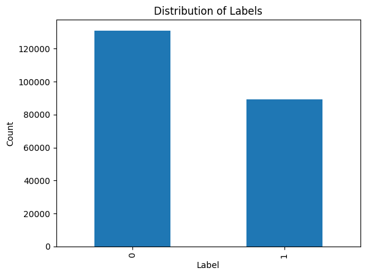

```python
labels['label'].value_counts().plot(kind='bar')
plt.title('Distribution of Labels')
plt.xlabel('Label')
plt.ylabel('Count')
plt.show()
```

## Image Visualization

Visualizing sample images from the dataset gives insight into the data quality and variance. Here, we can find the no cancer images are usually cleaner and contain more white space, less texture. In contrast, images with cancer present have more texture, more dots, and less white space.

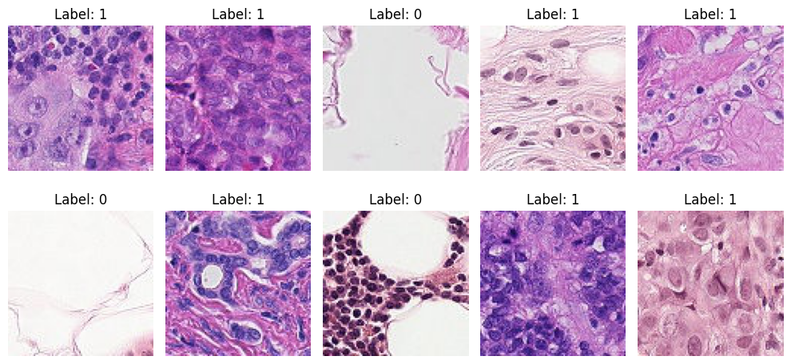

```python
def display_images(images, labels, num=10):
    plt.figure(figsize=(10, 5))
    for i in range(num):
        ax = plt.subplot(2, num // 2, i + 1)
        img = mpimg.imread(os.path.join(data_dir, 'train', images.iloc[i]))
        ax.imshow(img)
        ax.set_title('Label: ' + str(labels.iloc[i]))
        ax.axis('off')
    plt.tight_layout()
    plt.show()


# Visualize sample images with their labels
sample_images = labels.sample(n=10, random_state=0).reset_index(drop=True)
display_images(sample_images['id'], sample_images['label'])
```

## Data Preprocessing

Before training, we need to preprocess our data. This includes splitting the data into training and validation sets, normalizing image pixel values, and augmenting the data to improve model generalization.

```python
# Data preprocessing
labels['label'] = labels['label'].astype(str)
train_df, val_df = train_test_split(labels, test_size=0.2, random_state=0, stratify=labels['label'])
datagen = ImageDataGenerator(rescale=1. / 255, horizontal_flip=True, vertical_flip=True)

train_gen = datagen.flow_from_dataframe(
    dataframe=train_df,
    directory=os.path.join(data_dir, 'train'),
    x_col='id',
    y_col='label',
    target_size=(16, 16),
    class_mode='binary',
    batch_size=128
)

val_gen = datagen.flow_from_dataframe(
    dataframe=val_df,
    directory=os.path.join(data_dir, 'train'),
    x_col='id',
    y_col='label',
    target_size=(16, 16),
    class_mode='binary',
    batch_size=128
)
```

```
Found 176020 validated image filenames belonging to 2 classes.
Found 44005 validated image filenames belonging to 2 classes.
```

## Model Building

We define two CNN architectures here. One is a base shallow model with broader layers, and the other is a deeper but narrower model. The two models with different design philosophy will help us compare the performance of different architectures.

```python
def build_base_model(input_shape=(16, 16, 3)):
    model = Sequential([
        Conv2D(4, (3, 3), activation='relu', padding='same', input_shape=input_shape),
        MaxPooling2D(3, 3),
        Conv2D(8, (3, 3), activation='relu', padding='same'),
        MaxPooling2D(3, 3),
        Flatten(),
        Dense(4, activation='relu'),
        Dropout(0.3),
        Dense(1, activation='sigmoid')
    ])
    return model
```

```python
def build_deep_model(input_shape=(16, 16, 3)):
    model = Sequential([
        Conv2D(4, (3, 3), activation='relu', padding='same', input_shape=input_shape),
        Conv2D(4, (3, 3), activation='relu', padding='same'),
        MaxPooling2D(2, 2),
        Conv2D(4, (3, 3), activation='relu', padding='same'),
        Conv2D(4, (3, 3), activation='relu', padding='same'),
        MaxPooling2D(2, 2),
        Flatten(),
        Dense(2, activation='relu'),
        Dropout(0.3),
        Dense(1, activation='sigmoid')
    ])
    return model
```

## Model Experimentation

Here I try running experiments with different hyperparameters to fine-tune the models. This experiment with various combinations of optimizers and learning rates help to find the most effective settings for our models.

```python
def plot_metrics(history):
    plt.figure(figsize=(12, 5))
    plt.subplot(1, 2, 1)
    plt.plot(history.history['accuracy'], label='Training Accuracy')
    plt.plot(history.history['val_accuracy'], label='Validation Accuracy')
    plt.title('Training and Validation Accuracy')
    plt.legend()

    plt.subplot(1, 2, 2)
    plt.plot(history.history['loss'], label='Training Loss')
    plt.plot(history.history['val_loss'], label='Validation Loss')
    plt.title('Training and Validation Loss')
    plt.legend()

    plt.show()
```

```python
def experiment(model_fn, optimizer, learning_rate, epochs=3):
    model = model_fn()
    model.compile(optimizer=optimizer(learning_rate=learning_rate),
                  loss='binary_crossentropy',
                  metrics=['accuracy'])
    history = model.fit(train_gen, epochs=epochs, validation_data=val_gen, verbose=1)
    best_val_accuracy = max(history.history['val_accuracy'])
    plot_metrics(history)
    return model, history, best_val_accuracy
```

```
Testing Base Model with Adam and learning rate: 0.003
```

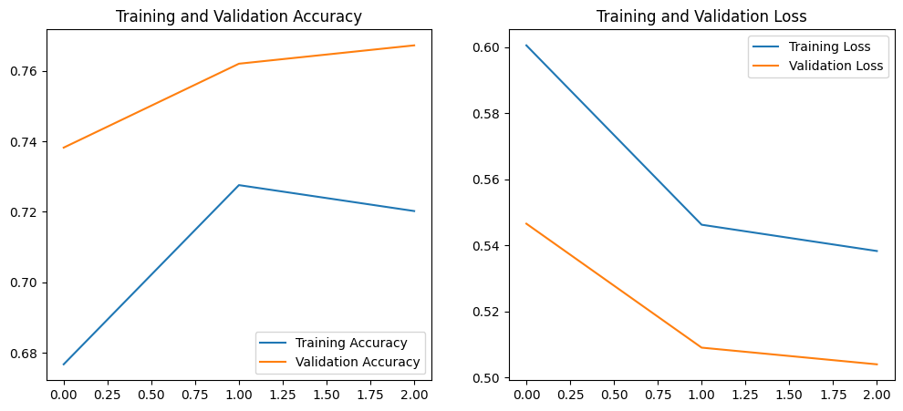

```
Testing Base Model with SGD and learning rate: 0.003
```

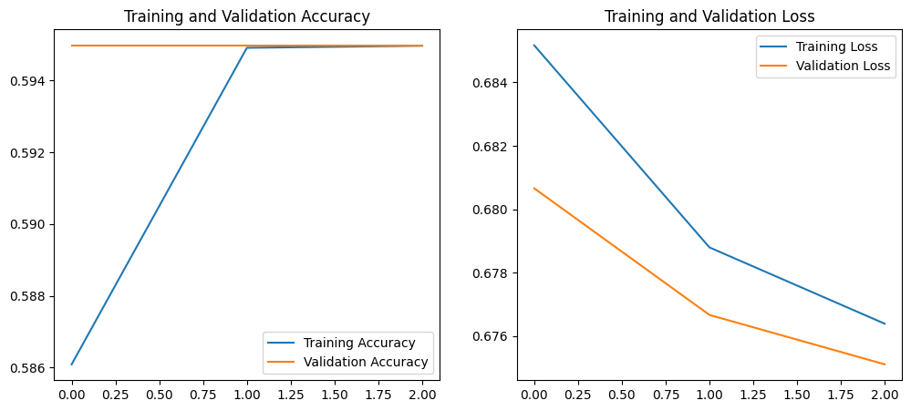

```
Testing Deep Model with Adam and learning rate: 0.003
```

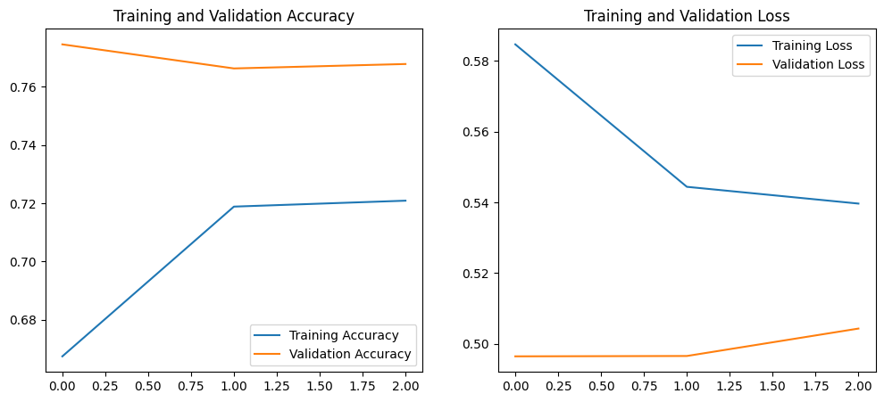

```
Testing Deep Model with SGD and learning rate: 0.003
```

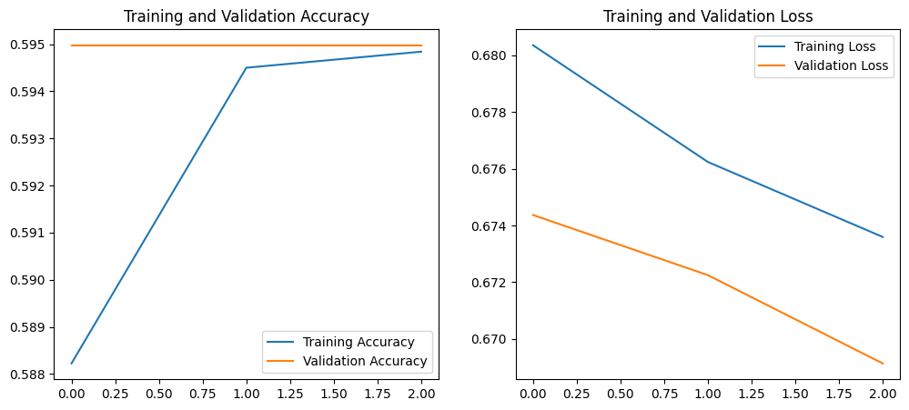

```
Best Base Model Settings: {'optimizer': 'Adam', 'learning_rate': 0.003, 'model': 'Base Model'} with accuracy: 0.7672536969184875
Best Deep Model Settings: {'optimizer': 'Adam', 'learning_rate': 0.003, 'model': 'Deep Model'} with accuracy: 0.774616539478302
```

```python
optimizers = [Adam, SGD]
learning_rates = [0.003]
batch_size = 512
train_gen.batch_size = batch_size
val_gen.batch_size = batch_size
best_base_model = None
best_deep_model = None
best_base_accuracy = 0
best_deep_accuracy = 0
best_base_settings = {}
best_deep_settings = {}

for model_fn, model_name in [(build_base_model, "Base Model"), (build_deep_model, "Deep Model")]:
    for optimizer in optimizers:
        for lr in learning_rates:
            print(f"\nTesting {model_name} with {optimizer.__name__} and learning rate: {lr}")
            model, history, val_accuracy = experiment(model_fn, optimizer, lr)
            if model_name == "Base Model" and val_accuracy > best_base_accuracy:
                best_base_accuracy = val_accuracy
                best_base_model = model
                best_base_settings = {'optimizer': optimizer.__name__, 'learning_rate': lr, 'model': model_name}
            elif model_name == "Deep Model" and val_accuracy > best_deep_accuracy:
                best_deep_accuracy = val_accuracy
                best_deep_model = model
                best_deep_settings = {'optimizer': optimizer.__name__, 'learning_rate': lr, 'model': model_name}

print(f"Best Base Model Settings: {best_base_settings} with accuracy: {best_base_accuracy}")
print(f"Best Deep Model Settings: {best_deep_settings} with accuracy: {best_deep_accuracy}")
```

```python
# Save the best base model
best_base_model.save('best_base_model.h5')
# Save the best deep model
best_deep_model.save('best_deep_model.h5')
```

## Model Evaluation

To further evaluate model performance, we generate confusion matrices and ROC curves. These metrics help us understand how well the model is performing in terms of true positive rate, false positive rate, and overall accuracy.

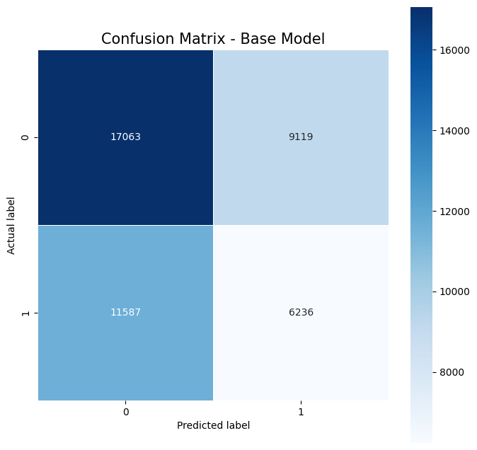

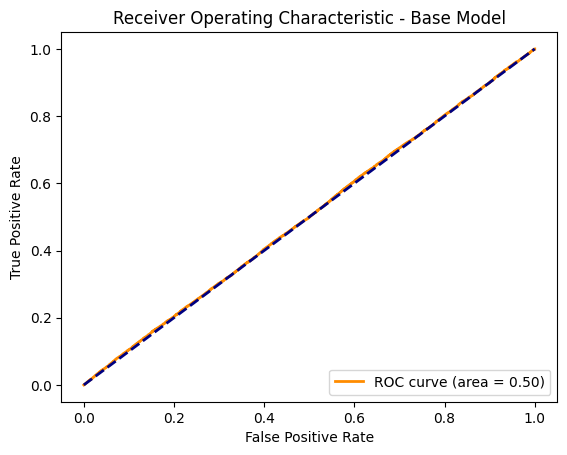

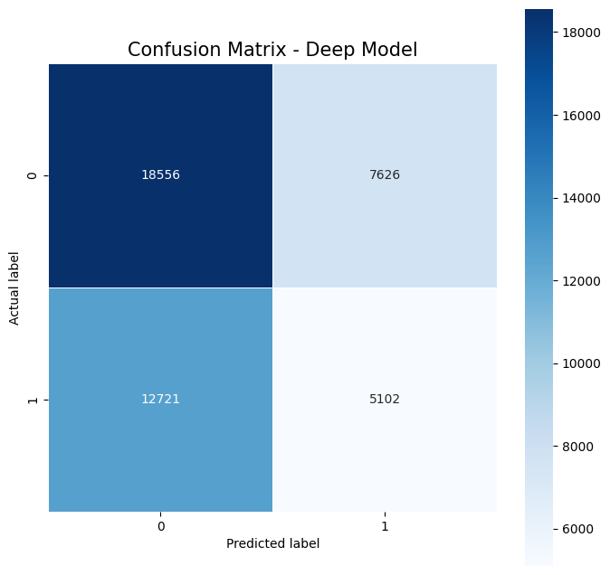

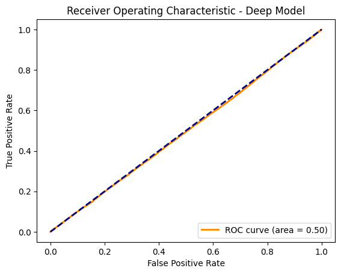

```python
def evaluate_and_compare_models(base_model, deep_model, data_generator):
    for model, label in [(base_model, "Base Model"), (deep_model, "Deep Model")]:
        evaluate_model(model, data_generator, label)


def evaluate_model(model, data_generator, label):
    predictions = model.predict(data_generator)
    y_pred = [1 if x > 0.5 else 0 for x in predictions]
    y_true = data_generator.classes

    # Confusion Matrix
    cm = confusion_matrix(y_true, y_pred)
    plt.figure(figsize=(8, 8))
    sns.heatmap(cm, annot=True, fmt="d", linewidths=.5, square=True, cmap='Blues')
    plt.ylabel('Actual label')
    plt.xlabel('Predicted label')
    plt.title(f'Confusion Matrix - {label}', size=15)
    plt.show()

    # ROC Curve
    fpr, tpr, _ = roc_curve(y_true, predictions)
    roc_auc = auc(fpr, tpr)
    plt.figure()
    plt.plot(fpr, tpr, color='darkorange', lw=2, label=f'ROC curve (area = {roc_auc:.2f})')
    plt.plot([0, 1], [0, 1], color='navy', lw=2, linestyle='--')
    plt.xlabel('False Positive Rate')
    plt.ylabel('True Positive Rate')
    plt.title(f'Receiver Operating Characteristic - {label}')
    plt.legend(loc="lower right")
    plt.show()


# Evaluate and compare both best models
evaluate_and_compare_models(best_base_model, best_deep_model, val_gen)
```

## Model Prediction

The best model from the experiments is deep model with Adam optimizer and learning rate 0.003. We load the best model and make predictions on the test set. The predictions are then saved to a CSV file for submission to Kaggle.

```python
best_model = load_model('best_deep_model.h5')
test_dir = os.path.join(data_dir, 'test')
test_df = pd.read_csv(os.path.join(data_dir, 'sample_submission.csv'))
test_df['id'] = test_df['id'].apply(lambda x: x + '.tif')

test_datagen = ImageDataGenerator(rescale=1. / 255)

test_gen = test_datagen.flow_from_dataframe(
    dataframe=test_df,
    directory=test_dir,
    x_col='id',
    y_col=None,
    target_size=(16, 16),
    class_mode=None,
    batch_size=128,
    shuffle=False
)
```

```
Found 57458 validated image filenames.
```

```python
predictions = best_model.predict(test_gen)
test_df['label'] = predictions

test_df['label'] = test_df['label'].apply(lambda x: 1 if x > 0.5 else 0)
test_df['id'] = test_df['id'].apply(lambda x: x.split('.')[0])
submission_file = 'sample_submission.csv'
test_df.to_csv(submission_file, index=False)
print(f"Sample submission file saved as {submission_file}")
```

```
Sample submission file saved as sample_submission.csv
```